# Exploring the BRFSS data

## Setup

```r
library(knitr)
opts_chunk$set(warning=FALSE, message=FALSE)
```

### Load packages

```r
library(ggplot2)

library(dplyr)
library(tidyr)
library(ggmosaic)
library(Hmisc)
library(xtable)
```

### Load data

```r
load("brfss2013.RData")
```

## Part 1: Data

The Center for Disease Control conducts the Behavioral Risk Factor Surveillance System (BRFSS) phone survey to collect information about preventative measures and risk factors associated with health problems.

The phone survey is a random sample. It is not a simple random sample. Most participating state agencies use a stratified sampling strategy called Disproportionate Strategy sample (DSS) to get the right sample sizes for certain populations for interest.

Since the survey is random, the results are generalizable to the population of interest – non-institutional adults (18 or older) living in the United States or participating territories.

(Note: The documentation states that the data are weighted to account for noncoverage and nonresonse rates within different segments of the population, and that these weights must be used in order to generalize results to the population [(more here)](https://www.cdc.gov/brfss/annual_data/2013/pdf/analysisofmodules_2013.pdf) ; however, using weights is beyond the scope of this course and are not used in this analysis.)

The sample size is large (nearly 492,000 records). As with any survey, there is a risk of non-response bias. The surveyers try to address this through stratified sampling and weighting samples. Since this exercise does not use weights, the results might reflect some nonresponse or noncoverage bias.

The study did not use random assignment. The survey is observational, and cannot be used to establish causation.

More information about the survey is available in this [overview](https://www.cdc.gov/brfss/annual_data/2013/pdf/overview_2013.pdf).

## Part 2: Research questions

**Research quesion 1:**

Medical professionals recommend that adults get between 7-9 hours of sleep per night ([Mayo Clinic](http://www.mayoclinic.org/healthy-lifestyle/adult-health/expert-answers/how-many-hours-of-sleep-are-enough/faq-20057898)). Intuition suggests that getting the recommended amount of daily sleep improves mental health. My first research question is as follows.

This is an important question for a few reasons.

- Using survey data provides an opportunity to evaluate a commonly accepted rule-of-thumb regarding sleep and health.
- Establishing connections between sleep and mental health could inform treatment options. Although the survey data cannot be used to make causations, it can verify a positive association that could motivate further experimental research.

**Research quesion 2:**

Military verterans traditionally have higher rates of smoking compared to the general population ([US Department of Veterans Affairs](https://www.publichealth.va.gov/smoking/professionals/tobacco-use.asp)). The next research question asks examines whether this tradition has changed over time.

**Do US veterans have a higher propensity to try smoking compared to the general US population and, if so, does this pattern decrease with younger veterans.**.

This question is important because of the the highly addictive nature of smoking. Trying smoking could lead to long-term smoking, which carries health risks. If veterans are more likely to try smoking, this puts their health at greater risk.

The age component is important for a few reasons. Among the general population, smoking rates have decreased. This might show up as lower smoking rates among younger age groups. Looking at smoking among different age groups might indicate if veterans have been affected by the larger societal shift, or if military smoking preventation programs are changing behavior among younger veterans.

**Research quesion 3:**

Experts recommend people incorporate physical activity into their daily lives. One rule of thumb is to get 30 minutes of physical activity each day ([Mayo Clinic](http://www.mayoclinic.org/healthy-lifestyle/fitness/expert-answers/exercise/faq-20057916)).

The survey provide an opportunity to evaluate this recommendation by examining whether or not a random sample of non-institionalized adults in the US who exercise experience fewer bad health days. This evaluation controls for the potential affects of health care coverage by diving the subjects into those who have health care and those who do not. My research question is:

**Do non-institutionalized adults in the US who get exercise report fewer bad health days after controlling for health care coverge?**

## Part 3: Exploratory data analysis

**Research quesion 1:**

This question examines two variables:

- *sleptim1*: the average amount of time the subject sleeps over a 24-hour period, and
- *menthlth*: the number of days the subject’s mental health was not good over a 30-day period.

The data contains a number of records that are either missing values for the *sleptim1* variable or the *menthlth* variable. There are also a number of records with unrealistic values, i.e. a value of > 30 for the number of days of not good mental health in a 30-day period, or >24 hours for average number of hours slept during the day. I removed reocords with missing values or values greater than 24 for *sletim1* and records with missing values or values greater than 30 for *menthlth*.

```r
brfss2013_cleaned<-
  filter(brfss2013,!(X_state %in% c(0,80)),menthlth<=30,sleptim1<=24) %>%
  filter(.,!is.na(menthlth),!is.na(sleptim1))
```

I then looked at the distribution and summary statistics for both the *menthlth* and *sleptim1* variables.

```r
summaryMnhlth<-brfss2013_cleaned %>%
  summarise(min=min(menthlth),'25%'=quantile(menthlth,.25),'50%'=quantile(menthlth,.5),
            mean=round(mean(menthlth),2),'75%'=quantile(menthlth,.75),max=max(menthlth),IQR=IQR(menthlth))

kable(summaryMnhlth)
```

| min | 25% | 50% | mean | 75% | max | IQR |
| --- | --- | --- | --- | --- | --- | --- |
| 0 | 0 | 0 | 3.34 | 2 | 30 | 2 |

The table above lists the summary statistics, and shows that at least half of respondents reported zero days of not good mental health.

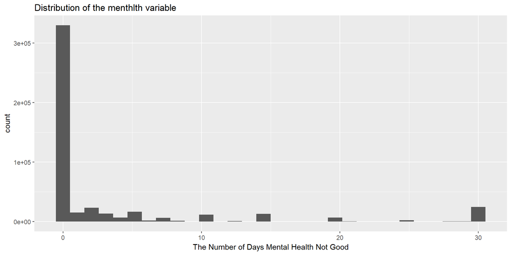

```r
ggplot(data=brfss2013_cleaned,aes(menthlth)) + geom_histogram()  + ggtitle("Distribution of the menthlth variable") + xlab("The Number of Days Mental Health Not Good")
```

This is also shown in the histogram above, which shows a unimodal distribution that is highly skewed to the right.

The average hours slept in a 24-hour period shows a more normal distribution, as shown in the table and histogram below.

```r
summarySleep<-brfss2013_cleaned %>%
  summarise(min=min(sleptim1),'25%'=quantile(sleptim1,.25),'50%'=quantile(sleptim1,.5),
            mean=round(mean(sleptim1),2),'75%'=quantile(sleptim1,.75),max=max(sleptim1),IQR=IQR(sleptim1))

kable(summarySleep)
```

| min | 25% | 50% | mean | 75% | max | IQR |
| --- | --- | --- | --- | --- | --- | --- |
| 1 | 6 | 7 | 7.05 | 8 | 24 | 2 |

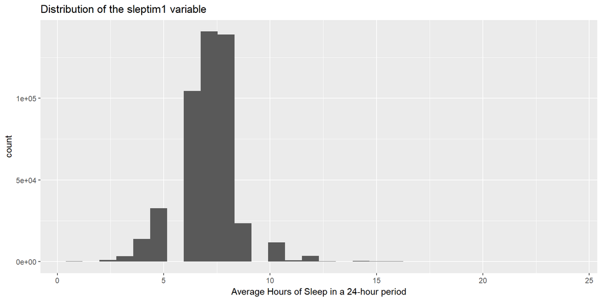

```r
ggplot(data=brfss2013_cleaned,aes(sleptim1)) + geom_histogram()  + ggtitle("Distribution of the sleptim1 variable") + xlab("Average Hours of Sleep in a 24-hour period")
```

To identify possible association between not good mental health days and getting the recommended amount of sleep, I created two categorical variables: a binary variable indicating whether or not the subject got enough sleep and a binary variable indicating whether the subject reported any bad mental health days.

```r
MhSleep <-
  mutate(brfss2013_cleaned,'Experienced Not Good Mental Health' = ifelse(menthlth>0,"Reported Not Good Mental Health", "Did Not Report Not Good Mental Health"),
         'Recommended Sleep'=ifelse(sleptim1>=7 & sleptim1<=10,"Yes - Recommended Sleep","No - Recommended Sleep")) %>%
  select(.,`Experienced Not Good Mental Health`,`Recommended Sleep`)
```

In the next step, I made crosstabulation tables of mental health experience and getting the recommended amount of sleep.

```r
t1<-addmargins(table(MhSleep[,1:2]))
t2<-prop.table(table(MhSleep[,1:2]),2)

kable(t1,format.args=list(big.mark=","))
```

|  | No - Recommended Sleep | Yes - Recommended Sleep | Sum |
| --- | --- | --- | --- |
| Did Not Report Not Good Mental Health | 96,452 | 233,532 | 329,984 |
| Reported Not Good Mental Health | 65,189 | 81,441 | 146,630 |
| Sum | 161,641 | 314,973 | 476,614 |

```r
kable(t2,format.args=list(digits=2))
```

|  | No - Recommended Sleep | Yes - Recommended Sleep |
| --- | --- | --- |
| Did Not Report Not Good Mental Health | 0.6 | 0.74 |
| Reported Not Good Mental Health | 0.4 | 0.26 |

The two tables summarize the data by the recommended sleep and mental health data. The first table shows counts; the second table shows proportions. The first table shows that most people did not report a bad mental health day experience. The table also show that most people reported getting the recommended amount of sleep per day.

The mosaic plot shows this pattern. Most people reported getting the recommended amount of sleep, and most people not report experiencing bad mental health. But those people who do not get the recommended amount of sleep report higher rates of not good mental health days.

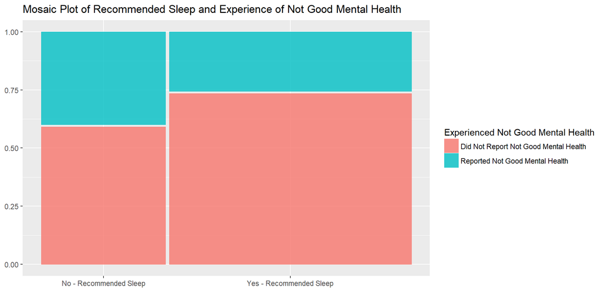

```r
ggplot(data=MhSleep) +
geom_mosaic(aes(x=product(`Recommended Sleep`),fill=`Experienced Not Good Mental Health`)) + ggtitle("Mosaic Plot of Recommended Sleep and Experience of Not Good Mental Health") + xlab(" ")
```

The results above suggest that there is a positive association between not getting the recommended amount of sleep and experiencing some form of not good mental health. The survey design suggests that this association can be generalized to non-insitutionalized adults in the United States.

More formal statistical testing is needed to determine if this association is significant.

Experimental test design is needed to determine any causation. Without randomized assignment, it is not possible to tell if bad mental health experiences effect sleep, whether sleep affects mental health, or the presence of some confounding variables (e.g. a stressful lifestyle) affects both mental health and sleep patterns.

**Research quesion 2:**

**Do US veterans have a higher propensity to try smoking compared to the general US population and, if so, does this pattern decrease with younger veterans.**.

This question involves looking at three variables:

- *veteran3*: which indicates whether or not the subject is a military veteran
- *smoke100*: this asks whether the subject has smoked more than 100 cigarettes; used to determine if the subject has tried smoking
- *ageg*: the imputed age of the subject within 6 age categories:
  - 1: Age 18-24
  - 2: Age 25-34
  - 3: Age 35-44
  - 4: Age 45-55
  - 5: Age 55-64
  - 6: Age 65+

The *smoke100* variables was chosen among others smoking related variables because of its higher response rate. Other variables related to smoking status had so many missing values that I was concerned they might introduction a response bias.

In this first step, I removed missing values in each of the three variables

```r
brfss2013_cleaned2<-
  select(brfss2013,X_age_g,smoke100,veteran3) %>%
  filter(.,!is.na(X_age_g),!is.na(smoke100),!is.na(veteran3))
```

The first thing I want to look at is whether the survey data shows higher rates of having smoked among veterans.

```r
summarySmokeV<-brfss2013_cleaned2 %>%
  transmute("Veteran Status" = ifelse(veteran3=="Yes","Yes - Veteran", "No - Veteran"),
            "Smoker Status" = ifelse(smoke100 == "Yes", "Yes - Have Smoked", "No - Have Not Smoked"))

t1<-addmargins(table(summarySmokeV[,1:2]))
t2<-prop.table(table(summarySmokeV[,1:2]),1)

kable(t1,format.args=list(big.mark=","))
```

|  | No - Have Not Smoked | Yes - Have Smoked | Sum |
| --- | --- | --- | --- |
| No - Veteran | 239,275 | 177,404 | 416,679 |
| Yes - Veteran | 22,144 | 37,604 | 59,748 |
| Sum | 261,419 | 215,008 | 476,427 |

```r
kable(t2,format.args=list(digits=2))
```

|  | No - Have Not Smoked | Yes - Have Smoked |
| --- | --- | --- |
| No - Veteran | 0.57 | 0.43 |
| Yes - Veteran | 0.37 | 0.63 |

The tables show that a larger proportion of veterans have smoked over 100 cigarettes than non-veterans - 63% versus 43%. The bar graph visualizes this higher propensity by comparing the proportion of veterans who have smoked with non-veterans.

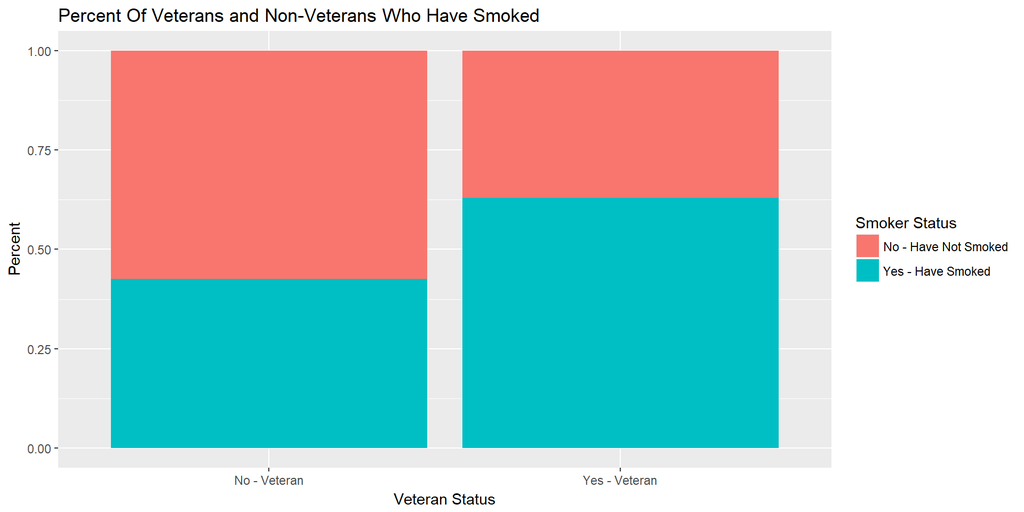

```r
ggplot(data=summarySmokeV, aes(x=`Veteran Status`)) + geom_bar(aes(fill=`Smoker Status`),position = "fill") + ggtitle("Percent Of Veterans and Non-Veterans Who Have Smoked") + ylab("Percent")
```

The next chart examines if rates of having tried smoking among both veterans and the general population are changing with age. Due to public awareness about the effects of smoking, smoking has become less popular. I expect the proportion of adults (both veterans and non-veterans) who have tried smoking to go down with age for two reasons. First, the question asks people if they have ever tried smoking over their entire life. Older respondents would be likely to have higher rates because they have had more time to try smoking compared with younger respondents. Second, recent efforts to prevent people from trying smoking would affect younger groups – many older respondents would have already tried smoking prior to these public health initiatives.

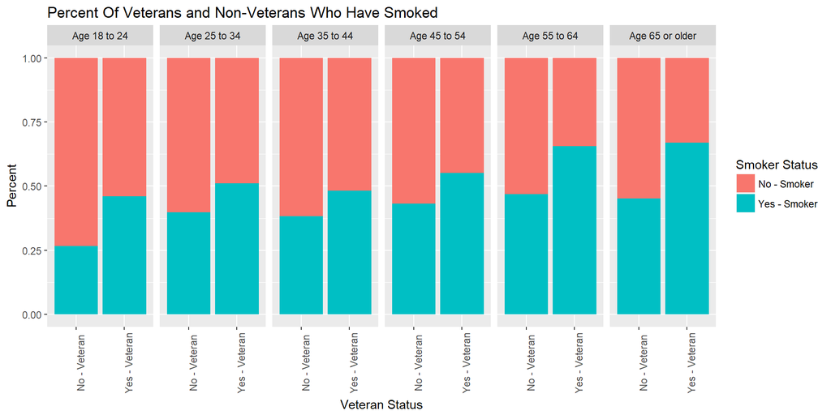

```r
summarySmokeV<-brfss2013_cleaned2 %>%
  transmute("Veteran Status" = ifelse(veteran3=="Yes","Yes - Veteran", "No - Veteran"),
            "Smoker Status" = ifelse(smoke100 == "Yes", "Yes - Smoker", "No - Smoker"),X_age_g=X_age_g)

ggplot(data=summarySmokeV, aes(x=`Veteran Status`)) + geom_bar(aes(fill=`Smoker Status`),position = "fill") + ggtitle("Percent Of Veterans and Non-Veterans Who Have Smoked") + ylab("Percent") + facet_grid(~X_age_g) + theme(axis.text.x = element_text(angle = 90))
```

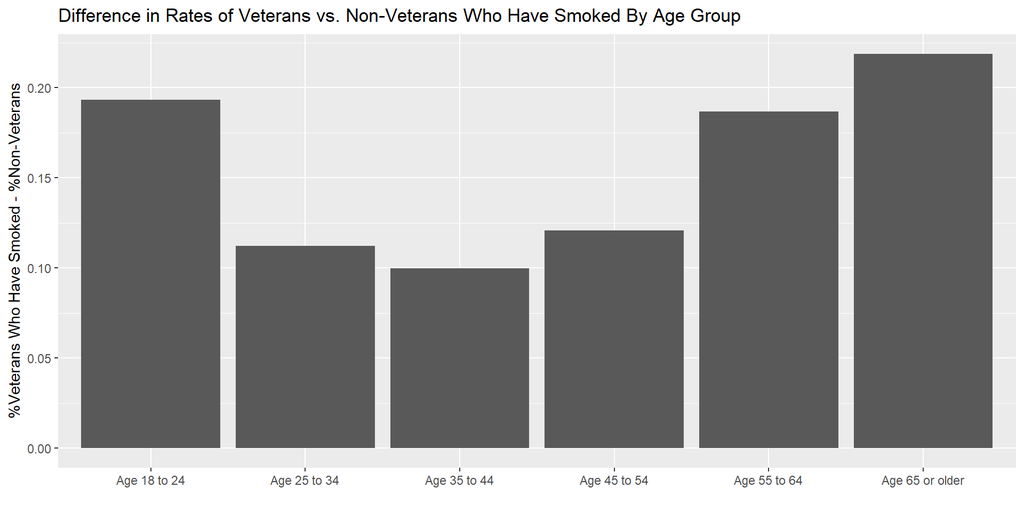

```r
trends<-brfss2013_cleaned2 %>%

  count(.,X_age_g,veteran3,smoke100) %>%
  #filter(smoke100=="Yes") %>%
  spread(.,smoke100,n) %>%
  mutate(Total=Yes + No, Percent_Smoke=Yes/Total) %>%
  select(.,X_age_g,veteran3,Percent_Smoke) %>%
  spread(veteran3,Percent_Smoke) %>%
  mutate("Difference in Starting Smoking"=Yes-No)

ggplot(data=trends,aes(x=X_age_g)) + geom_col(aes(y=`Difference in Starting Smoking`)) + ggtitle("Difference in Rates of Veterans vs. Non-Veterans Who Have Smoked By Age Group") + ylab("%Veterans Who Have Smoked - %Non-Veterans") + xlab(" ")
```

In the younger age group, however, this trend begins to reverse – the difference in the proportions of veterans who have tried smoking compared to non-veterans increase. This suggests that veterans’ higher propensity to smoke compared to the general population does not decrease with age.

The results above suggest that US veterans do have a higher propensity to try smoking compared to the general population, and that this relatively higher propensity does not clearly decrease with age.

The survey design gives me confidence that these results generalize to the non-instituionalized adult population in the US; however,this information does not imply causation. Without random assignment and experimental design, I cannot say being a veteran causes a higher propenity to try smoking. Furthermore, stastistical testing is also required to determine if these differences are statistically significant.

**Research quesion 3:**

**Do non-institutionalized adults in the US who get exercise report fewer bad health days after controlling for health care coverge?**

My research question looks at three variables:

*exerany2*: whether or not the subject has exercised in the last 30 days  
*physhlth*: the number of days of not good physical health days in a month  
*hlthpln1*: binary variable indicating whether subject has health care coverage

The first step is to eliminate records with missing values for any of the three variables, and unrealistic values for *physhlth* (i.e. greater than 30 days).

```r
brfss2013_cleaned3<-
  filter(brfss2013,!(X_state %in% c(0,80)),physhlth<=30) %>%
  filter(.,!is.na(exerany2),!is.na(physhlth),!is.na(hlthpln1))
```

Next I looked at the distribution of how many days of subjects reported bad health.

```r
summaryHealth<-brfss2013_cleaned3 %>%
  summarise(min=min(physhlth),'25%'=quantile(physhlth,.25),'50%'=quantile(physhlth,.5),
            mean=round(mean(physhlth),2),'75%'=quantile(physhlth,.75),max=max(physhlth),IQR=IQR(physhlth))

kable(summaryHealth)
```

| min | 25% | 50% | mean | 75% | max | IQR |
| --- | --- | --- | --- | --- | --- | --- |
| 0 | 0 | 0 | 4.35 | 3 | 30 | 3 |

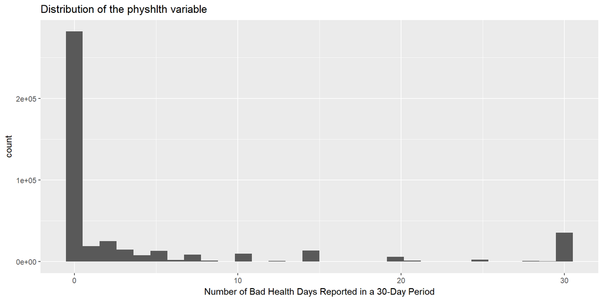

```r
ggplot(data=brfss2013_cleaned3,aes(physhlth)) + geom_histogram()  + ggtitle("Distribution of the physhlth variable") + xlab("Number of Bad Health Days Reported in a 30-Day Period")
```

The histogram shows an unimodal disbribution that is skewed to the right. Both the graph and table indicate that most subjects did not report bad health days in a 30-day period. Although I don’t think the distribution is bimodal, there is slight peak at 30 days, the maximum value possible for this variable.

The next step compares the distribution of bad health days for those who exercised and those who did not.

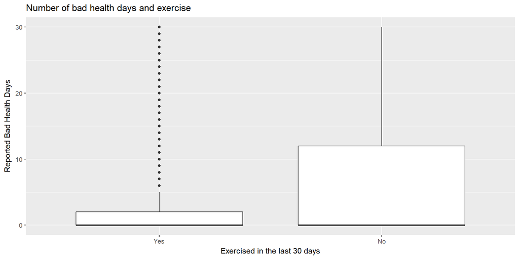

```r
ggplot(brfss2013_cleaned3, aes(y=physhlth, x=exerany2)) +
    geom_boxplot() + ggtitle("Number of bad health days and exercise") + xlab("Exercised in the last 30 days") +
  ylab("Reported Bad Health Days")
```

The boxplot shows that the distribution for both groups is also skewed to the right. The median value of bad health days for both groups is zero; however, it does look like the group that did not exercise reported more bad health days.

In the next step I looked at whether those who exercise report lower rates of experiencing a bad health day. This required recoding the *physhlth* variable into a binary variable with “yes” equal to whether or not they reported any bad health days.

The table below summarizes the percent of those who reported bad days based on whether they exercised. The group who did not exercise reported a greater proportion of bad health days compared to those who did not exercise – 47 percent vs. 33 percent.

```r
summaryEx<-
  transmute(brfss2013_cleaned3,'Experienced Bad Health Day' = ifelse(physhlth>0,"Reported Bad Health Day", "Did Not Report Bad Health Day"),
         'Exercise'=ifelse(exerany2=="Yes","Exercised","Did Not Exercise"), 'Health Care Access'=ifelse(hlthpln1=="Yes","Has Health Care", "Does Not Have Health Care"))

tab1<- summaryEx %>% select(.,`Experienced Bad Health Day`,`Exercise`)

t2<-prop.table(table(tab1[,1:2]),2)
kable(t2,format.args=list(digits=2))
```

|  | Did Not Exercise | Exercised |
| --- | --- | --- |
| Did Not Report Bad Health Day | 0.53 | 0.67 |
| Reported Bad Health Day | 0.47 | 0.33 |

Since acccess to health care could also affect the number of bad health days, I looked at what happens to this relationship when accounting for the *hlthpln1* variable.

The table below looks at bad health days and exercise for just those subjects who have health care coverage.

```r
tab3<- summaryEx %>%
  filter(.,`Health Care Access`=="Has Health Care") %>%
  select(.,`Experienced Bad Health Day`,`Exercise`)

t3<-prop.table(table(tab3[,1:2]),2)
kable(t3,format.args=list(digits=2))
```

|  | Did Not Exercise | Exercised |
| --- | --- | --- |
| Did Not Report Bad Health Day | 0.52 | 0.67 |
| Reported Bad Health Day | 0.48 | 0.33 |

The table shows this higher percentage of non-exercisers reporting bad health days holds true even among the subgroup of subjects who have health care coverage.

The table below looks at the other subgroup – those who do not have health care coverage.

```r
tab4<- summaryEx %>%
  filter(.,`Health Care Access`=="Does Not Have Health Care") %>%
  select(.,`Experienced Bad Health Day`,`Exercise`)

t4<-prop.table(table(tab4[,1:2]),2)
kable(t4,format.args=list(digits=2))
```

|  | Did Not Exercise | Exercised |
| --- | --- | --- |
| Did Not Report Bad Health Day | 0.56 | 0.64 |
| Reported Bad Health Day | 0.44 | 0.36 |

Among those who do not have health care coverage, the percent of those who report bad health days is 9 percent higher for those who do not exercise. This table shows the same pattern – people who do not have health care coverage and do not exercise report higher rates of experiencing bad health days.

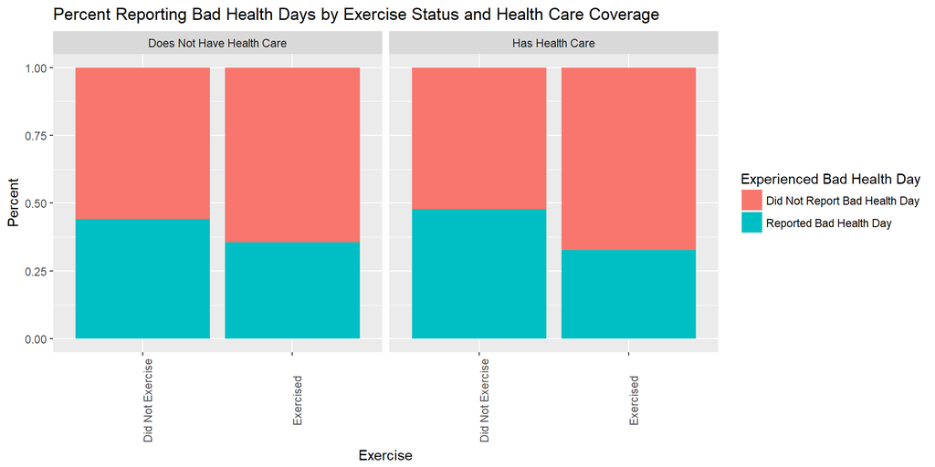

```r
summaryEx2 <- summaryEx %>% mutate(.,`Exercise`=as.factor(`Exercise`))

ggplot(data=summaryEx2, aes(x=`Exercise`)) + geom_bar(aes(fill=`Experienced Bad Health Day`),position = "fill") + ggtitle("Percent Reporting Bad Health Days by Exercise Status and Health Care Coverage") + ylab("Percent") + facet_grid(~`Health Care Access`) + theme(axis.text.x = element_text(angle = 90))
```

The bar chart above visually shows this pattern. A higher percent of those who did not exercise reported bad health days in both the health care coverage and no-coverage groups.

The analysis above suggests that non-institutionalized adults in the US who get exercise do have fewer bad health days even after for controlling for health care coverge. The survey data suggest an association, but not causation. Other confounding factors (such as age) could be affecting all three variables. Random assignment is needed to establish causation.

**References**

*Behavioral Risk Factor Surveillance System, Module Data for Analysis for 2013 BRFSS, August 2014, https://www.cdc.gov/brfss/annual_data/2013/pdf/analysisofmodules_2013.pdf*

*Behavioral Risk Factor Surveillance System, Overview: BRFSS 2013, August 15, 2014, (https://www.cdc.gov/brfss/annual_data/2013/pdf/overview_2013.pdf)*

*Mayo Clinic, How many hours of sleep are enough for good health?,http://www.mayoclinic.org/healthy-lifestyle/adult-health/expert-answers/how-many-hours-of-sleep-are-enough/faq-20057898*

*Mayo Clinic,(http://www.mayoclinic.org/healthy-lifestyle/fitness/expert-answers/exercise/faq-20057916)*

*US Department of Veterans Affairs,(https://www.publichealth.va.gov/smoking/professionals/tobacco-use.asp)*